# Lab 9: Generative Art

Author

Lily Cook

```r
library(tidyverse)
library(tibble)
library(ggforce)
library(deldir)
library(ggthemes)
library(tictoc)
library(ambient)
library(purrr)
library(tidyr)
library(stringr)
library(sf)
```

## Midnight Stargazing

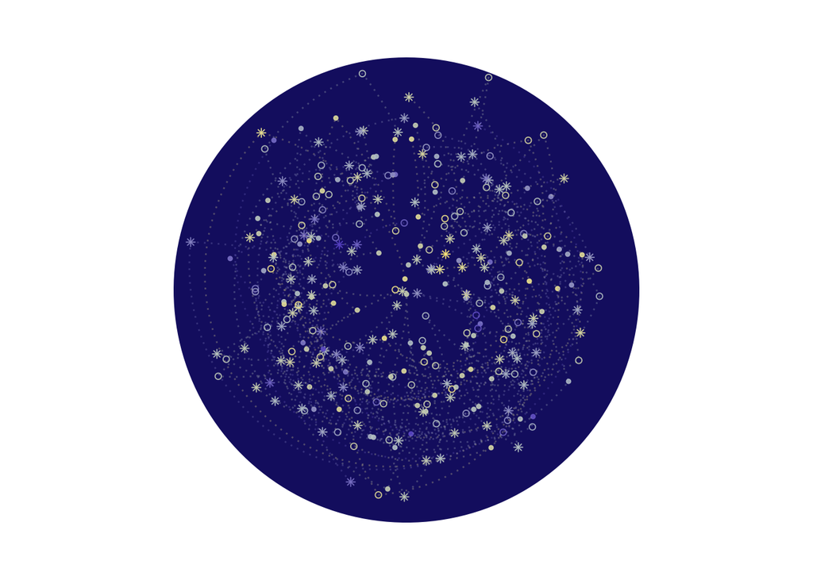

```r
# generating random variables using various distributions
w <- rpois(300, 70)
x <- rgamma(300, 3)
y <- rnorm(300, 50, 200)
z <- rbinom(300, 200, 0.7)
a <- sample(c('a', 'b', 'c'), replace = T, size = 300)

data <- cbind(w, x, y, z, a) # combining into df


# create gradient color pallete
pal <- colorRampPalette(c("lightgoldenrod1","azure3", "slateblue"))

art_colors <- pal(n_distinct(w))

#plot

ggplot(data, aes(x = y, y = z)) +
  geom_point(aes(shape = a, color = w), show.legend = F, alpha = 0.9) + #add points
  geom_line(aes(group = w, color = w), linetype = 3, show.legend = F, alpha = 0.3)+ # connect points
  scale_shape_manual(values = c("a" = 20, "b" = 8, "c" = 21)) + # change shapes of points
  scale_color_manual(values = art_colors) + # change colors
  coord_radial() + #circle
  theme_void() + #remove everything
  theme(panel.background = element_rect(fill = "midnightblue", color = "midnightblue")) # background color
```

#### Description

Gazing at the midnight stars, your eyes drift between the celestial bodies. The stars seem to be randomly scattered across the sky…..

#### Code choices

By adding `coord_radial()`, the art piece now has a circular shape. Setting the background fill and color gives the same midnight blue color as the backdrop of the piece. Adjusting the alpha in the `geoms` adjusts the opacity of the shapes on the plot. `scale_color_manual` allows me to choose a palette and `scale_shape_manual` allows me to choose the shapes the points will be. Lastly, using `theme_void` removes all titles, axis lines, etc. to give the appearance of art.